# Background and Context

The Policy Maker of the "Visit With Us" wants to enable and establish a viable business model to expand the customer base.

A viable business model is a central concept that helps you to understand the existing ways of doing the business and how to change the ways for the benefit of the tourism sector.

One of the ways to expand the customer base is to introduce a new offering of packages.Currently, there are 5 types of packages the company is offering - Basic, Standard, Deluxe, Super Deluxe, King. Looking at the data of the last year, we observed that 18% of the customers purchased the packages.

The company in the last campaign contacted the customers at random without looking at the available information. However, this time company is now planning to launch a new product i.e. Wellness Tourism Package. Wellness Tourism is defined as Travel that allows the traveler to maintain, enhance or kick-start a healthy lifestyle, and support or increase one's sense of well-being, and wants to harness the available data of existing and potential customers to make the marketing expenditure more efficient.

# Objective

We need to build a model that will help the marketing department to identify the potential customers who have a higher probability of purchasing the travel package.

#### Questions to address:

1. To predict whether a customer will buy a travel package or not.
2. Which variables are most significant.
3. Which segment of customers should be targeted more.

### Dataset

#### Dataset Used for Modeling:

- CustomerID: Unique customer ID
- ProdTaken: Whether the customer has purchased a package or not (0: No, 1: Yes)
- Age: Age of customer
- TypeofContact: How customer was contacted (Company Invited or Self Inquiry)
- CityTier: City tier depends on the development of a city, population, facilities, and living standards. The categories are ordered i.e. Tier 1 > Tier 2 > Tier 3
- Occupation: Occupation of customer
- Gender: Gender of customer
- NumberOfPersonVisiting: Total number of persons planning to take the trip with the customer
- PreferredPropertyStar: Preferred hotel property rating by customer
- MaritalStatus: Marital status of customer
- NumberOfTrips: Average number of trips in a year by customer
- Passport: The customer has a passport or not (0: No, 1: Yes)
- OwnCar: Whether the customers own a car or not (0: No, 1: Yes)
- NumberOfChildrenVisiting: Total number of children with age less than 5 planning to take the trip with the customer
- Designation: Designation of the customer in the current organization
- MonthlyIncome: Gross monthly income of the customer
- PitchSatisfactionScore: Sales pitch satisfaction score
- ProductPitched: Product pitched by the salesperson
- NumberOfFollowups: Total number of follow-ups has been done by the salesperson after the sales pitch
- DurationOfPitch: Duration of the pitch by a salesperson to the customer

## Import Libraries

```python
import pandas as pd
import numpy as np
from sklearn import metrics
import matplotlib.pyplot as plt
%matplotlib inline
import warnings
warnings.filterwarnings('ignore')
import seaborn as sns
from sklearn.model_selection import train_test_split
from sklearn.model_selection import GridSearchCV
from sklearn import metrics
from sklearn.tree import DecisionTreeClassifier
from sklearn.ensemble import AdaBoostClassifier, GradientBoostingClassifier
#To install xgboost library use - !pip install xgboost
from xgboost import XGBClassifier
from sklearn.ensemble import BaggingClassifier, RandomForestClassifier
from sklearn.linear_model import LogisticRegression
from sklearn.metrics import confusion_matrix, classification_report, accuracy_score, precision_score, recall_score,f1_score,roc_auc_score
```

```python
tourismData = pd.read_csv("Tourism.csv")

# make a copy
data = tourismData.copy()
```

#### View the first 5 rows of dataset

```python
data.head()
```

|  | CustomerID | ProdTaken | Age | TypeofContact | CityTier | DurationOfPitch | Occupation | Gender | NumberOfPersonVisiting | NumberOfFollowups | ProductPitched | PreferredPropertyStar | MaritalStatus | NumberOfTrips | Passport | PitchSatisfactionScore | OwnCar | NumberOfChildrenVisiting | Designation | MonthlyIncome |
| --- | --- | --- | --- | --- | --- | --- | --- | --- | --- | --- | --- | --- | --- | --- | --- | --- | --- | --- | --- | --- |
| 0 | 200000 | 1 | 41.0 | Self Enquiry | 3 | 6.0 | Salaried | Female | 3 | 3.0 | Deluxe | 3.0 | Single | 1.0 | 1 | 2 | 1 | 0.0 | Manager | 20993.0 |
| 1 | 200001 | 0 | 49.0 | Company Invited | 1 | 14.0 | Salaried | Male | 3 | 4.0 | Deluxe | 4.0 | Divorced | 2.0 | 0 | 3 | 1 | 2.0 | Manager | 20130.0 |
| 2 | 200002 | 1 | 37.0 | Self Enquiry | 1 | 8.0 | Free Lancer | Male | 3 | 4.0 | Basic | 3.0 | Single | 7.0 | 1 | 3 | 0 | 0.0 | Executive | 17090.0 |
| 3 | 200003 | 0 | 33.0 | Company Invited | 1 | 9.0 | Salaried | Female | 2 | 3.0 | Basic | 3.0 | Divorced | 2.0 | 1 | 5 | 1 | 1.0 | Executive | 17909.0 |
| 4 | 200004 | 0 | NaN | Self Enquiry | 1 | 8.0 | Small Business | Male | 2 | 3.0 | Basic | 4.0 | Divorced | 1.0 | 0 | 5 | 1 | 0.0 | Executive | 18468.0 |

#### View the last 5 rows of dataset

```python
data.tail()
```

|  | CustomerID | ProdTaken | Age | TypeofContact | CityTier | DurationOfPitch | Occupation | Gender | NumberOfPersonVisiting | NumberOfFollowups | ProductPitched | PreferredPropertyStar | MaritalStatus | NumberOfTrips | Passport | PitchSatisfactionScore | OwnCar | NumberOfChildrenVisiting | Designation | MonthlyIncome |
| --- | --- | --- | --- | --- | --- | --- | --- | --- | --- | --- | --- | --- | --- | --- | --- | --- | --- | --- | --- | --- |
| 4883 | 204883 | 1 | 49.0 | Self Enquiry | 3 | 9.0 | Small Business | Male | 3 | 5.0 | Deluxe | 4.0 | Unmarried | 2.0 | 1 | 1 | 1 | 1.0 | Manager | 26576.0 |
| 4884 | 204884 | 1 | 28.0 | Company Invited | 1 | 31.0 | Salaried | Male | 4 | 5.0 | Basic | 3.0 | Single | 3.0 | 1 | 3 | 1 | 2.0 | Executive | 21212.0 |
| 4885 | 204885 | 1 | 52.0 | Self Enquiry | 3 | 17.0 | Salaried | Female | 4 | 4.0 | Standard | 4.0 | Married | 7.0 | 0 | 1 | 1 | 3.0 | Senior Manager | 31820.0 |
| 4886 | 204886 | 1 | 19.0 | Self Enquiry | 3 | 16.0 | Small Business | Male | 3 | 4.0 | Basic | 3.0 | Single | 3.0 | 0 | 5 | 0 | 2.0 | Executive | 20289.0 |
| 4887 | 204887 | 1 | 36.0 | Self Enquiry | 1 | 14.0 | Salaried | Male | 4 | 4.0 | Basic | 4.0 | Unmarried | 3.0 | 1 | 3 | 1 | 2.0 | Executive | 24041.0 |

#### Check the shape of the dataset

```python
data.shape
```

```
(4888, 20)
```

#### Check for any duplicates

```python
data[data.duplicated()].count()
```

```
CustomerID                  0
ProdTaken                   0
Age                         0
TypeofContact               0
CityTier                    0
DurationOfPitch             0
Occupation                  0
Gender                      0
NumberOfPersonVisiting      0
NumberOfFollowups           0
ProductPitched              0
PreferredPropertyStar       0
MaritalStatus               0
NumberOfTrips               0
Passport                    0
PitchSatisfactionScore      0
OwnCar                      0
NumberOfChildrenVisiting    0
Designation                 0
MonthlyIncome               0
dtype: int64
```

- **The dataset has no duplicates**

#### Delete the Customer ID column since it does not help our analysis

```python
data.drop('CustomerID' , axis=1 , inplace=True)
```

#### Check the datatypes of the columns

```python
data.info()
```

```
<class 'pandas.core.frame.DataFrame'>
RangeIndex: 4888 entries, 0 to 4887
Data columns (total 19 columns):
 #   Column                    Non-Null Count  Dtype
---  ------                    --------------  -----
 0   ProdTaken                 4888 non-null   int64
 1   Age                       4662 non-null   float64
 2   TypeofContact             4863 non-null   object
 3   CityTier                  4888 non-null   int64
 4   DurationOfPitch           4637 non-null   float64
 5   Occupation                4888 non-null   object
 6   Gender                    4888 non-null   object
 7   NumberOfPersonVisiting    4888 non-null   int64
 8   NumberOfFollowups         4843 non-null   float64
 9   ProductPitched            4888 non-null   object
 10  PreferredPropertyStar     4862 non-null   float64
 11  MaritalStatus             4888 non-null   object
 12  NumberOfTrips             4748 non-null   float64
 13  Passport                  4888 non-null   int64
 14  PitchSatisfactionScore    4888 non-null   int64
 15  OwnCar                    4888 non-null   int64
 16  NumberOfChildrenVisiting  4822 non-null   float64
 17  Designation               4888 non-null   object
 18  MonthlyIncome             4655 non-null   float64
dtypes: float64(7), int64(6), object(6)
memory usage: 725.7+ KB
```

#### Convert ProdTaken, Passport, OwnCar to boolen datatypes

```python
# Convert the int datatypes for ProdTaken, Passport, OwnCar to boolen datatypes columns to  bool type

bool_cols = ['ProdTaken', 'Passport', 'OwnCar' ]

for col in bool_cols:
    data[col] = data[col].astype('bool')

data.info()
```

```
<class 'pandas.core.frame.DataFrame'>
RangeIndex: 4888 entries, 0 to 4887
Data columns (total 19 columns):
 #   Column                    Non-Null Count  Dtype
---  ------                    --------------  -----
 0   ProdTaken                 4888 non-null   bool
 1   Age                       4662 non-null   float64
 2   TypeofContact             4863 non-null   object
 3   CityTier                  4888 non-null   int64
 4   DurationOfPitch           4637 non-null   float64
 5   Occupation                4888 non-null   object
 6   Gender                    4888 non-null   object
 7   NumberOfPersonVisiting    4888 non-null   int64
 8   NumberOfFollowups         4843 non-null   float64
 9   ProductPitched            4888 non-null   object
 10  PreferredPropertyStar     4862 non-null   float64
 11  MaritalStatus             4888 non-null   object
 12  NumberOfTrips             4748 non-null   float64
 13  Passport                  4888 non-null   bool
 14  PitchSatisfactionScore    4888 non-null   int64
 15  OwnCar                    4888 non-null   bool
 16  NumberOfChildrenVisiting  4822 non-null   float64
 17  Designation               4888 non-null   object
 18  MonthlyIncome             4655 non-null   float64
dtypes: bool(3), float64(7), int64(3), object(6)
memory usage: 625.4+ KB
```

#### Convert TypeofContact, Gender, MaritalStatus to categorical datatypes

```python
# Convert the object datatypes for TypeofContact, Gender, MaritalStatus to categorical datatypes

obj_cols = ['TypeofContact', 'Gender', 'MaritalStatus','Occupation', 'ProductPitched', 'Designation' ]

for col in obj_cols:
    data[col] = data[col].astype('category')

data.info()
```

```
<class 'pandas.core.frame.DataFrame'>
RangeIndex: 4888 entries, 0 to 4887
Data columns (total 19 columns):
 #   Column                    Non-Null Count  Dtype
---  ------                    --------------  -----
 0   ProdTaken                 4888 non-null   bool
 1   Age                       4662 non-null   float64
 2   TypeofContact             4863 non-null   category
 3   CityTier                  4888 non-null   int64
 4   DurationOfPitch           4637 non-null   float64
 5   Occupation                4888 non-null   category
 6   Gender                    4888 non-null   category
 7   NumberOfPersonVisiting    4888 non-null   int64
 8   NumberOfFollowups         4843 non-null   float64
 9   ProductPitched            4888 non-null   category
 10  PreferredPropertyStar     4862 non-null   float64
 11  MaritalStatus             4888 non-null   category
 12  NumberOfTrips             4748 non-null   float64
 13  Passport                  4888 non-null   bool
 14  PitchSatisfactionScore    4888 non-null   int64
 15  OwnCar                    4888 non-null   bool
 16  NumberOfChildrenVisiting  4822 non-null   float64
 17  Designation               4888 non-null   category
 18  MonthlyIncome             4655 non-null   float64
dtypes: bool(3), category(6), float64(7), int64(3)
memory usage: 425.9 KB
```

#### Check the unique counts in Gender column

```python
data['Gender'].value_counts()
```

```
Male       2916
Female     1817
Fe Male     155
Name: Gender, dtype: int64
```

- It appears that Gender 155 rows have the Gender value as "Fe Male". This appears to be a typo for "Female". Therefore we will edit this to be "Female" by removing space

#### Replace the rows that have "Fe Male" to "Female"

```python
# Replace Fe Male to Female in Gender column
data.loc[(data.Gender == 'Fe Male'),'Gender']='Female'
```

```python
# Check the count of Gender column
data['Gender'].value_counts()
```

```
Male       2916
Female     1972
Fe Male       0
Name: Gender, dtype: int64
```

#### Reset the categories for Gender to remove the. "Fe Male"

```python
# Remove the "Fe Male" as category for Gender column
data.Gender = data.Gender.cat.remove_categories(['Fe Male'])
```

```python
data['Gender'].value_counts()
```

```
Male      2916
Female    1972
Name: Gender, dtype: int64
```

#### Check for missing values

```python
data.isnull().sum()
```

```
ProdTaken                     0
Age                         226
TypeofContact                25
CityTier                      0
DurationOfPitch             251
Occupation                    0
Gender                        0
NumberOfPersonVisiting        0
NumberOfFollowups            45
ProductPitched                0
PreferredPropertyStar        26
MaritalStatus                 0
NumberOfTrips               140
Passport                      0
PitchSatisfactionScore        0
OwnCar                        0
NumberOfChildrenVisiting     66
Designation                   0
MonthlyIncome               233
dtype: int64
```

- **We could either inpute the missing values by mean of the column or delete them. Since missing data is a small number compared to the total dataset (5000 rows), we will go ahead and drop them**

#### Drop the missing values

```python
data.dropna( inplace=True)
```

```python
data.isnull().sum()
```

```
ProdTaken                   0
Age                         0
TypeofContact               0
CityTier                    0
DurationOfPitch             0
Occupation                  0
Gender                      0
NumberOfPersonVisiting      0
NumberOfFollowups           0
ProductPitched              0
PreferredPropertyStar       0
MaritalStatus               0
NumberOfTrips               0
Passport                    0
PitchSatisfactionScore      0
OwnCar                      0
NumberOfChildrenVisiting    0
Designation                 0
MonthlyIncome               0
dtype: int64
```

- All missing values have been handled

#### Look at the summary of dataset

```python
data.describe().T
```

|  | count | mean | std | min | 25% | 50% | 75% | max |
| --- | --- | --- | --- | --- | --- | --- | --- | --- |
| Age | 4128.0 | 37.231831 | 9.174521 | 18.0 | 31.0 | 36.0 | 43.0 | 61.0 |
| CityTier | 4128.0 | 1.663275 | 0.920640 | 1.0 | 1.0 | 1.0 | 3.0 | 3.0 |
| DurationOfPitch | 4128.0 | 15.584787 | 8.398142 | 5.0 | 9.0 | 14.0 | 20.0 | 127.0 |
| NumberOfPersonVisiting | 4128.0 | 2.949370 | 0.718818 | 1.0 | 2.0 | 3.0 | 3.0 | 5.0 |
| NumberOfFollowups | 4128.0 | 3.741521 | 1.006786 | 1.0 | 3.0 | 4.0 | 4.0 | 6.0 |
| PreferredPropertyStar | 4128.0 | 3.578488 | 0.795031 | 3.0 | 3.0 | 3.0 | 4.0 | 5.0 |
| NumberOfTrips | 4128.0 | 3.295300 | 1.856300 | 1.0 | 2.0 | 3.0 | 4.0 | 22.0 |
| PitchSatisfactionScore | 4128.0 | 3.060804 | 1.363064 | 1.0 | 2.0 | 3.0 | 4.0 | 5.0 |
| NumberOfChildrenVisiting | 4128.0 | 1.223595 | 0.852685 | 0.0 | 1.0 | 1.0 | 2.0 | 3.0 |
| MonthlyIncome | 4128.0 | 23178.464147 | 4506.614622 | 1000.0 | 20751.0 | 22418.0 | 25301.0 | 98678.0 |

### Insights :

- *Age* seems to be evenly distributed
- *DurationOfPitch* seems to have outliers and a wider spread.
- *Income* has a max value thatis greater than the mean,median, and 75th percentile possibly implying the column has a lot of outliers. We will explore this further in EDA section
- *NumberOfPersonVisiting* seems to be evenly distributed
- *NumberOfTrips* seems to have outliers and a wider spread.

### Outlier Detection

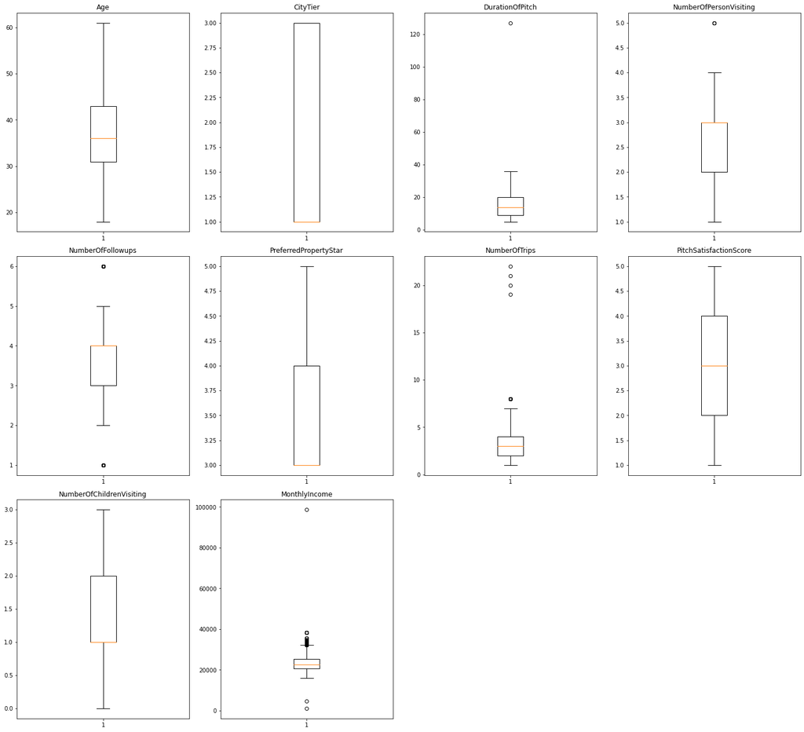

```python
numerical_col = data.select_dtypes(include=np.number).columns.tolist()
plt.figure(figsize=(20, 30))

for i, variable in enumerate(numerical_col):
    plt.subplot(5, 4, i + 1)
    plt.boxplot(data[variable], whis=1.5)
    plt.tight_layout()
    plt.title(variable)

plt.show()
```

- Income has a lot of upper outliers
- Number of Trips has a some outliers

### Treating Outliers

```python
data[data['DurationOfPitch']>37].count()
```

```
ProdTaken                   1
Age                         1
TypeofContact               1
CityTier                    1
DurationOfPitch             1
Occupation                  1
Gender                      1
NumberOfPersonVisiting      1
NumberOfFollowups           1
ProductPitched              1
PreferredPropertyStar       1
MaritalStatus               1
NumberOfTrips               1
Passport                    1
PitchSatisfactionScore      1
OwnCar                      1
NumberOfChildrenVisiting    1
Designation                 1
MonthlyIncome               1
dtype: int64
```

- It appears that there is only one datapoint where the Duration of pitch is greater than 37. Therefore this seems like a true outlier since a typical sales pitch cannot last for more than 30 minutes. Therefore we will remove this outlier (which is just one data point)

#### Delete the outlier for Duration of pitch

```python
# Drop the outlier for duration
data.drop(data[data['DurationOfPitch'] >37].index , inplace=True)
```

#### Check the Outliers for MonthlyIncome

```python
print("Total users with monthly income < 15000 : " , data['MonthlyIncome'][data['MonthlyIncome']<15000].count())
print("Total users with monthly income > 40000 : " , data['MonthlyIncome'][data['MonthlyIncome']>40000].count())
```

```
Total users with monthly income < 15000 :  2
Total users with monthly income > 40000 :  1
```

- Out of total of over 4k customers, only 2 of them have income <15k and 1 of them >40k. Therefore we will treat these as outliers and go ahead and delete them

```python
# Delete the rows where monthly income is <15k and >40k
data.drop(data[data['MonthlyIncome'] <15000].index , inplace=True)
data.drop(data[data['MonthlyIncome'] >40000].index , inplace=True)
```

### Preliminary Data Analysis

```python
## Check how many users have taken product in the past
data['ProdTaken'].value_counts()
```

```
False    3327
True      797
Name: ProdTaken, dtype: int64
```

- Roughly about 800 users have taken the product in the past

### Exploratory Data Analysis

### Univariate analysis

```python
# function to plot a boxplot and a histogram along the same scale.


def histogram_boxplot(data, feature, figsize=(12, 7), kde=False, bins=None):
    """
    Boxplot and histogram combined

    data: dataframe
    feature: dataframe column
    figsize: size of figure (default (12,7))
    kde: whether to show the density curve (default False)
    bins: number of bins for histogram (default None)
    """
    f2, (ax_box2, ax_hist2) = plt.subplots(
        nrows=2,  # Number of rows of the subplot grid= 2
        sharex=True,  # x-axis will be shared among all subplots
        gridspec_kw={"height_ratios": (0.25, 0.75)},
        figsize=figsize,
    )  # creating the 2 subplots
    sns.boxplot(
        data=data, x=feature, ax=ax_box2, showmeans=True, color="violet"
    )  # boxplot will be created and a star will indicate the mean value of the column
    sns.histplot(
        data=data, x=feature, kde=kde, ax=ax_hist2, bins=bins, palette="winter"
    ) if bins else sns.histplot(
        data=data, x=feature, kde=kde, ax=ax_hist2
    )  # For histogram
    ax_hist2.axvline(
        data[feature].mean(), color="green", linestyle="--"
    )  # Add mean to the histogram
    ax_hist2.axvline(
        data[feature].median(), color="black", linestyle="-"
    )  # Add median to the histogram
```

#### Visualize Age

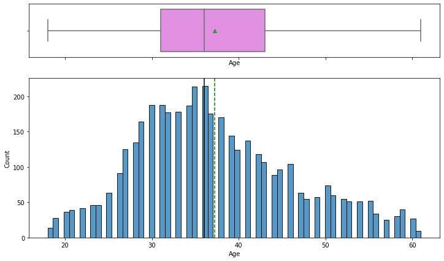

```python
# Plot the histogram a nd boxplot of independant variable Age
plt.figure(figsize=(20,10))
histogram_boxplot(data, "Age", bins=70)
```

#### Visualize DurationOfPitch

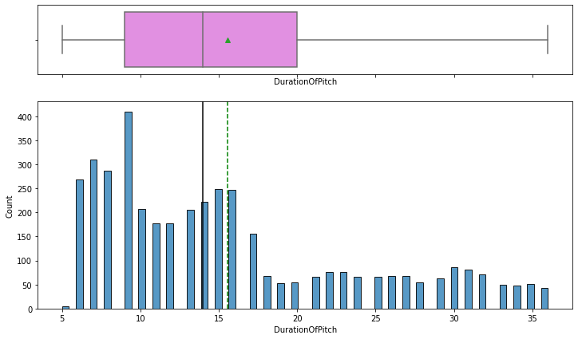

```python
# Plot the histogram and boxplot of independant variable DurationOfPitch
plt.figure(figsize=(20,10))
histogram_boxplot(data, "DurationOfPitch", bins=70)
```

#### Visualize NumberOfTrips

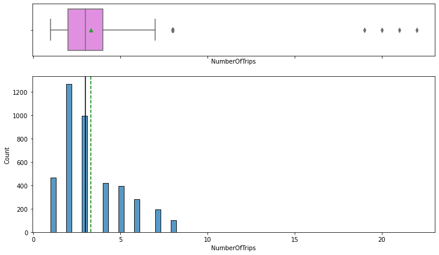

```python
# Plot the histogram and boxplot of independant variable NumberOfTrips
plt.figure(figsize=(20,10))
histogram_boxplot(data, "NumberOfTrips", bins=70)
```

#### Visualize MonthlyIncome

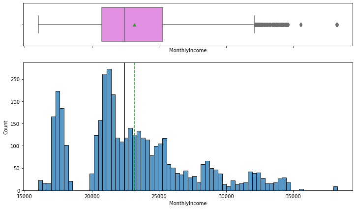

```python
# Plot the histogram and boxplot of independant variable Monthly Income
plt.figure(figsize=(20,10))
histogram_boxplot(data, "MonthlyIncome", bins=70)
```

### Visualization for Independant Boolean & Categorical Variables

#### Function to create labeled barplots

```python
# function to create labeled barplots

def labeled_barplot(data, feature, perc=False, n=None):
    """
    Barplot with percentage at the top

    data: dataframe
    feature: dataframe column
    perc: whether to display percentages instead of count (default is False)
    n: displays the top n category levels (default is None, i.e., display all levels)
    """

    total = len(data[feature])  # length of the column
    count = data[feature].nunique()
    if n is None:
        plt.figure(figsize=(count + 2, 6))
    else:
        plt.figure(figsize=(n + 2, 6))

    plt.xticks(rotation=90, fontsize=15)
    ax = sns.countplot(
        data=data,
        x=feature,
        palette="Paired",
        order=data[feature].value_counts().index[:n].sort_values(),
    )

    for p in ax.patches:
        if perc == True:
            label = "{:.1f}%".format(
                100 * p.get_height() / total
            )  # percentage of each class of the category
        else:
            label = p.get_height()  # count of each level of the category

        x = p.get_x() + p.get_width() / 2  # width of the plot
        y = p.get_height()  # height of the plot

        ax.annotate(
            label,
            (x, y),
            ha="center",
            va="center",
            size=12,
            xytext=(0, 5),
            textcoords="offset points",
        )  # annotate the percentage

    plt.show()  # show the plot
```

#### Visualize Passport

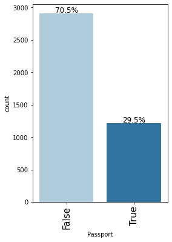

```python
# Plot the barplot of independant variable Passport
labeled_barplot(data, "Passport", perc=True)
```

#### Visualize NumberOfTrips

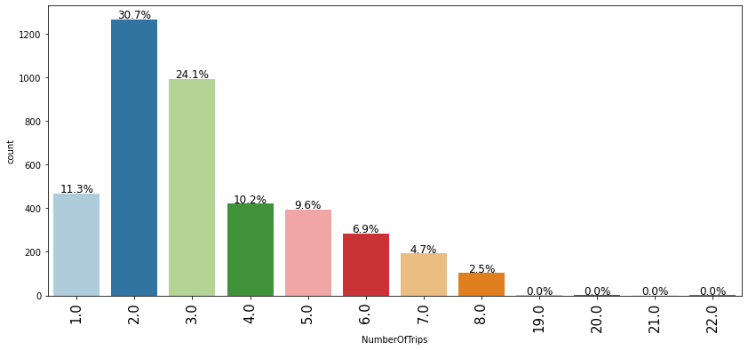

```python
# Plot the barplot of independant variable NumberOfTrips
labeled_barplot(data, "NumberOfTrips", perc=True)
```

#### Visualize OwnCar

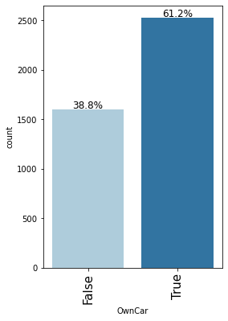

```python
# Plot the barplot of independant variable OwnCar
labeled_barplot(data, "OwnCar", perc=True)
```

#### Visualize NumberOfChildrenVisiting

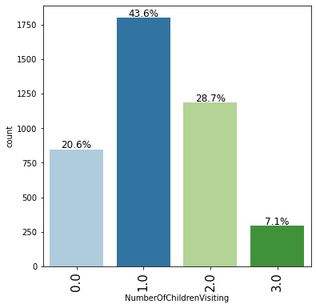

```python
# Plot the barplot of independant variable NumberOfChildrenVisiting
labeled_barplot(data, "NumberOfChildrenVisiting", perc=True)
```

#### Visualize NumberOfPersonVisiting

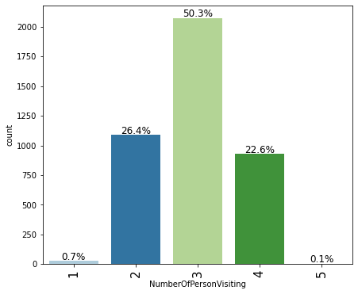

```python
# Plot the barplot of independant variable NumberOfPersonVisiting
labeled_barplot(data, "NumberOfPersonVisiting", perc=True)
```

#### Visualize PreferredPropertyStar

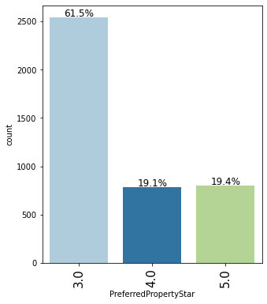

```python
# Plot the barplot of independant variable PreferredPropertyStar
labeled_barplot(data, "PreferredPropertyStar", perc=True)
```

#### Visualize NumberOfFollowups

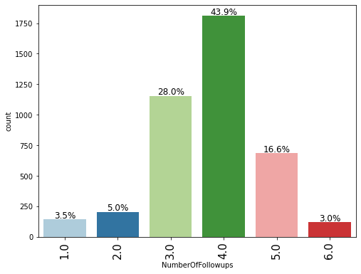

```python
# Plot the barplot of independant variable NumberOfFollowups
labeled_barplot(data, "NumberOfFollowups", perc=True)
```

### Observations:

- Age of the customers follows a normal distribution and has no outliers
- Monthly Income seems to be right skewed with 2 peaks.
- About 70% of the customers do not have a passport
- Roughly 50% of the customers tend to take 2 to 3 trips per year
- Roughly about 60% of the customers own a car
- Over 70% of the customers have 1 or 2 children
- Almost all of the families (about 99% of them) travel in a group of 2 to 4
- About 60% of the customers have preferred property star of 3, with the others preferring 4 or 5.
- About 44% of the followups done by sales team comprise of 4 followups

## Bivariate Analysis

### Heatmap

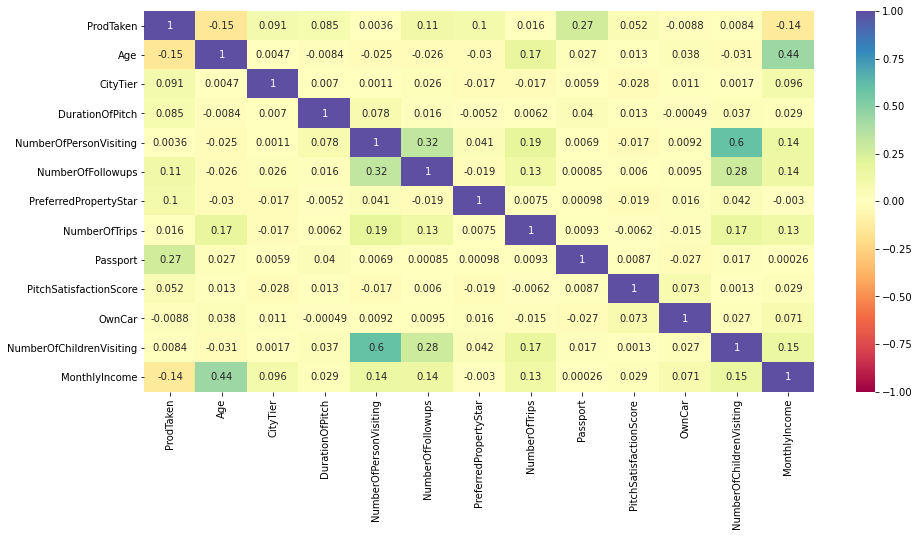

```python
# Plot the heatmap to check for correlations
plt.figure(figsize=(15, 7))
sns.heatmap(data.corr(), annot=True, vmin=-1, vmax=1, cmap="Spectral")
plt.show()
```

### Pairplot to visualize the correlations

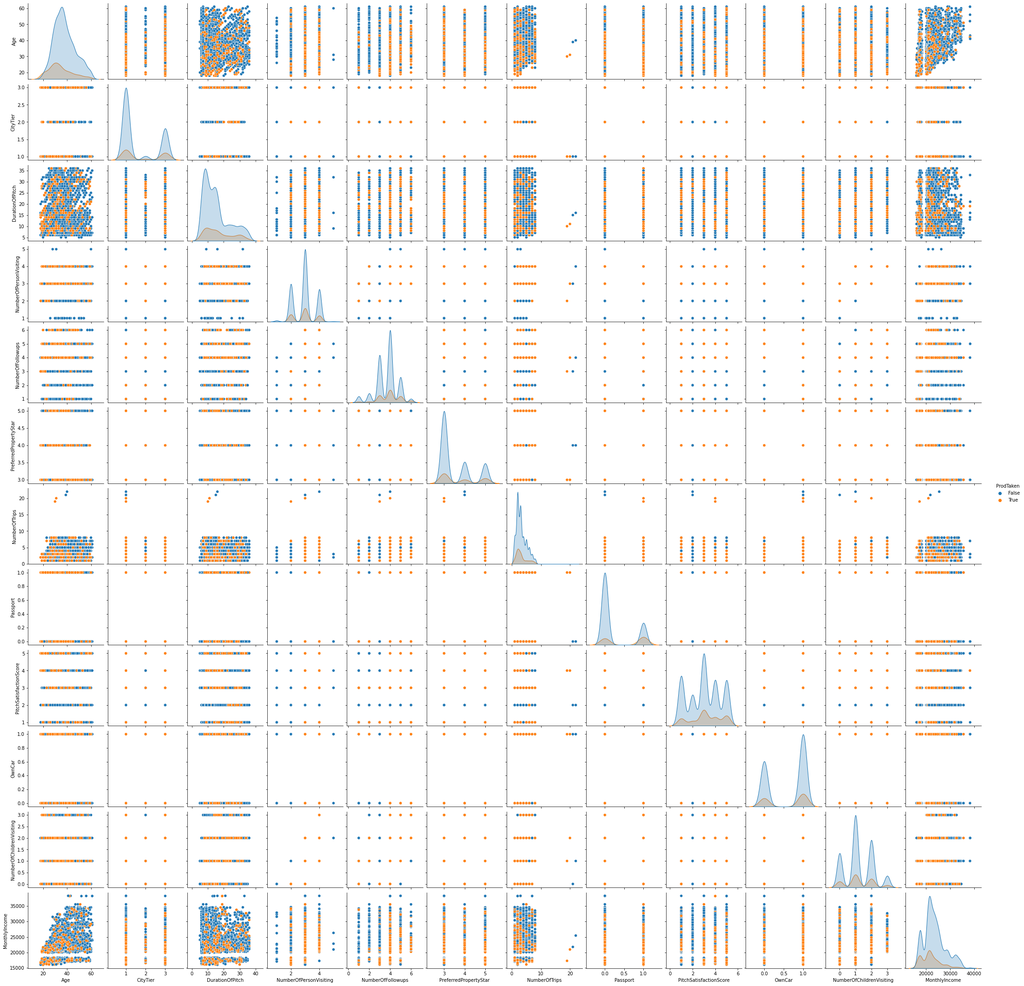

```python
# Build the pair plot to see visualize the correlations
sns.pairplot(data=data, hue="ProdTaken")
plt.show()
```

### Plot Products Taken (Dependent Variable) Vs Independant Variables:

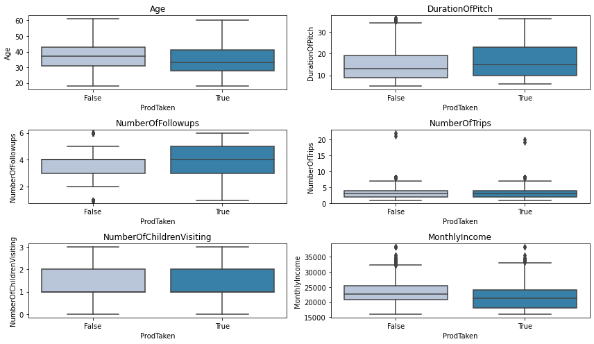

```python
### Plot Personal Loan vs Age, DurationOfPitch, NumberOfFollowups,NumberOfTrips, PitchSatisfactionScore ,
# NumberOfChildrenVisiting , MonthlyIncome
cols = data[
    [
        "Age",
        "DurationOfPitch",
        "NumberOfFollowups",
        "NumberOfTrips",
        "NumberOfChildrenVisiting",
        "MonthlyIncome"
    ]
].columns.tolist()
plt.figure(figsize=(12, 7))

for i, variable in enumerate(cols):
    plt.subplot(3, 2, i + 1)
    sns.boxplot(data["ProdTaken"], data[variable], palette="PuBu")
    plt.tight_layout()
    plt.title(variable)
plt.show()
```

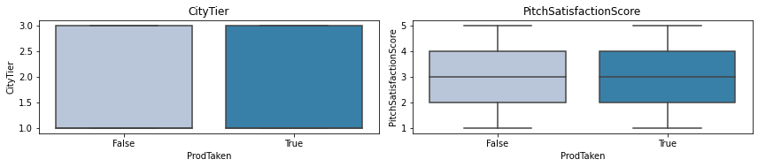

```python
### Plot Personal Loan vs Age, DurationOfPitch, NumberOfFollowups,NumberOfTrips, PitchSatisfactionScore ,
# NumberOfChildrenVisiting , MonthlyIncome
cols = data[
    [
        "CityTier",
        "PitchSatisfactionScore"
    ]
].columns.tolist()
plt.figure(figsize=(12, 7))

for i, variable in enumerate(cols):
    plt.subplot(3, 2, i + 1)
    sns.boxplot(data["ProdTaken"], data[variable], palette="PuBu")
    plt.tight_layout()
    plt.title(variable)
plt.show()
```

```python
data.info()
```

```
<class 'pandas.core.frame.DataFrame'>
Int64Index: 4124 entries, 0 to 4887
Data columns (total 19 columns):
 #   Column                    Non-Null Count  Dtype
---  ------                    --------------  -----
 0   ProdTaken                 4124 non-null   bool
 1   Age                       4124 non-null   float64
 2   TypeofContact             4124 non-null   category
 3   CityTier                  4124 non-null   int64
 4   DurationOfPitch           4124 non-null   float64
 5   Occupation                4124 non-null   category
 6   Gender                    4124 non-null   category
 7   NumberOfPersonVisiting    4124 non-null   int64
 8   NumberOfFollowups         4124 non-null   float64
 9   ProductPitched            4124 non-null   category
 10  PreferredPropertyStar     4124 non-null   float64
 11  MaritalStatus             4124 non-null   category
 12  NumberOfTrips             4124 non-null   float64
 13  Passport                  4124 non-null   bool
 14  PitchSatisfactionScore    4124 non-null   int64
 15  OwnCar                    4124 non-null   bool
 16  NumberOfChildrenVisiting  4124 non-null   float64
 17  Designation               4124 non-null   category
 18  MonthlyIncome             4124 non-null   float64
dtypes: bool(3), category(6), float64(7), int64(3)
memory usage: 551.6 KB
```

### Plot the Visualizations for Boolean Columns Vs "Products Acceptance?"

```python
data.info()
```

```
<class 'pandas.core.frame.DataFrame'>
Int64Index: 4124 entries, 0 to 4887
Data columns (total 19 columns):
 #   Column                    Non-Null Count  Dtype
---  ------                    --------------  -----
 0   ProdTaken                 4124 non-null   bool
 1   Age                       4124 non-null   float64
 2   TypeofContact             4124 non-null   category
 3   CityTier                  4124 non-null   int64
 4   DurationOfPitch           4124 non-null   float64
 5   Occupation                4124 non-null   category
 6   Gender                    4124 non-null   category
 7   NumberOfPersonVisiting    4124 non-null   int64
 8   NumberOfFollowups         4124 non-null   float64
 9   ProductPitched            4124 non-null   category
 10  PreferredPropertyStar     4124 non-null   float64
 11  MaritalStatus             4124 non-null   category
 12  NumberOfTrips             4124 non-null   float64
 13  Passport                  4124 non-null   bool
 14  PitchSatisfactionScore    4124 non-null   int64
 15  OwnCar                    4124 non-null   bool
 16  NumberOfChildrenVisiting  4124 non-null   float64
 17  Designation               4124 non-null   category
 18  MonthlyIncome             4124 non-null   float64
dtypes: bool(3), category(6), float64(7), int64(3)
memory usage: 551.6 KB
```

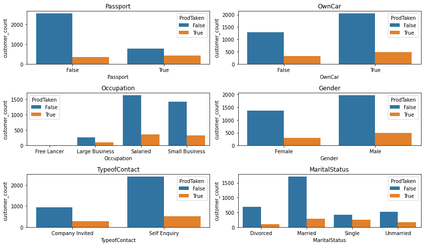

```python
### Plot barplot - Personal Loan vs Securities_Account, CD_Account, Online, and CreditCard

cols = data[
    [
        "Passport",
        "OwnCar",
        "Occupation",
        "Gender",
        "TypeofContact",
        "MaritalStatus"
    ]
].columns.tolist()
plt.figure(figsize=(12, 7))

for i, variable in enumerate(cols):
    if variable != 'ProdTaken':
        plt.subplot(3, 2, i + 1)
        data_plt = data.groupby([data['ProdTaken'],data[variable]]).agg(customer_count = (variable , 'count')).reset_index()
        sns.barplot(data=data_plt,hue='ProdTaken',x=variable , y='customer_count')
        plt.tight_layout()
        plt.title(variable)
plt.show()
```

```python
# print the statistics for the above plotted variables

print(data['Passport'].groupby([data['ProdTaken'] , data['Passport']]).count())
print("\n\n" , data['OwnCar'].groupby([data['ProdTaken'] , data['OwnCar']]).count())
print("\n\n" ,data['Occupation'].groupby([data['ProdTaken'] , data['Occupation']]).count())
print("\n\n" ,data['Gender'].groupby([data['ProdTaken'] , data['Gender']]).count())
print("\n\n" ,data['TypeofContact'].groupby([data['ProdTaken'] , data['TypeofContact']]).count())
print("\n\n" ,data['MaritalStatus'].groupby([data['ProdTaken'] , data['MaritalStatus']]).count())
```

```
ProdTaken  Passport
False      False       2548
           True         779
True       False        360
           True         437
Name: Passport, dtype: int64


 ProdTaken  OwnCar
False      False     1283
           True      2044
True       False      316
           True       481
Name: OwnCar, dtype: int64


 ProdTaken  Occupation
False      Free Lancer          0
           Large Business     268
           Salaried          1638
           Small Business    1421
True       Free Lancer          2
           Large Business     111
           Salaried           359
           Small Business     325
Name: Occupation, dtype: int64


 ProdTaken  Gender
False      Female    1363
           Male      1964
True       Female     299
           Male       498
Name: Gender, dtype: int64


 ProdTaken  TypeofContact
False      Company Invited     934
           Self Enquiry       2393
True       Company Invited     275
           Self Enquiry        522
Name: TypeofContact, dtype: int64


 ProdTaken  MaritalStatus
False      Divorced          683
           Married          1706
           Single            422
           Unmarried         516
True       Divorced          105
           Married           283
           Single            243
           Unmarried         166
Name: MaritalStatus, dtype: int64
```

```python
print("{}% of the users who did not accept travel package have passport & {}% of the users who accepted travel package have passport".format( round(779/(2548+779),1)*100 , round(437/(360+437),1)*100 ))

print("{}% of the users who did not accept travel package own a car & {}% of the users who accepted travel package own a car".format( round(2044/(1283+2044),1)*100 , round(481/(481+316),1)*100 ))

print("{}% of the users who did not accept travel package are either salaried or own a small business  & {}% of the users who accepted travel package are either salaried or own a small business".format( round((1638+1421)/(1638+1421+268),1)*100 , round((359+325)/(359+325+111),1)*100 ))

print("{}% of the users who did not accept travel package are Male & {}% of the users who accepted travel package are male ".format( round(1964/(1964+1363),1)*100 , round(498/(498+299),1)*100 ))

print("{}% of the users who did not accept travel package were customers who self enquired & {}% of the users who accepted travel package were customers who self enquired ".format( round(2393/(2393+934),1)*100 , round(522/(522+275),1)*100 ))

print("{}% of the users who did not accept travel package are either married or divorced & {}% of the users who accepted travel package are either married or divorced ".format( round((1706+683)/(1706+683+422+516),1)*100 , round((283+105)/(283+105+243+166),1)*100 ))

# print("\n {}% of the users who did not accept personal loan have CD account & {}% of the users who accepted personal loan have a CD account".format( round(162/(4306+162),2)*100 , round(140/(340+140),1)*100 ))

# print("\n {}% of the users who did not accept personal loan use Online & {}% of the users who accepted personal loan use Online banking".format( round(2663/(1805+2663),1)*100 , round(291/(291+189),1)*100 ))

# print("\n {}% of the users who did not accept personal loan use credit card from different bank & {}% of the users who accepted personal loan use credit card from different bank".format( round(1312/(1312+3156),1)*100 , round(143/(143+337),1)*100 ))
```

```
20.0% of the users who did not accept travel package have passport & 50.0% of the users who accepted travel package have passport
60.0% of the users who did not accept travel package own a car & 60.0% of the users who accepted travel package own a car
90.0% of the users who did not accept travel package are either salaried or own a small business  & 90.0% of the users who accepted travel package are either salaried or own a small business
60.0% of the users who did not accept travel package are Male & 60.0% of the users who accepted travel package are male
70.0% of the users who did not accept travel package were customers who self enquired & 70.0% of the users who accepted travel package were customers who self enquired
70.0% of the users who did not accept travel package are either married or divorced & 50.0% of the users who accepted travel package are either married or divorced
```

```python
data.info()
```

```
<class 'pandas.core.frame.DataFrame'>
Int64Index: 4124 entries, 0 to 4887
Data columns (total 19 columns):
 #   Column                    Non-Null Count  Dtype
---  ------                    --------------  -----
 0   ProdTaken                 4124 non-null   bool
 1   Age                       4124 non-null   float64
 2   TypeofContact             4124 non-null   category
 3   CityTier                  4124 non-null   int64
 4   DurationOfPitch           4124 non-null   float64
 5   Occupation                4124 non-null   category
 6   Gender                    4124 non-null   category
 7   NumberOfPersonVisiting    4124 non-null   int64
 8   NumberOfFollowups         4124 non-null   float64
 9   ProductPitched            4124 non-null   category
 10  PreferredPropertyStar     4124 non-null   float64
 11  MaritalStatus             4124 non-null   category
 12  NumberOfTrips             4124 non-null   float64
 13  Passport                  4124 non-null   bool
 14  PitchSatisfactionScore    4124 non-null   int64
 15  OwnCar                    4124 non-null   bool
 16  NumberOfChildrenVisiting  4124 non-null   float64
 17  Designation               4124 non-null   category
 18  MonthlyIncome             4124 non-null   float64
dtypes: bool(3), category(6), float64(7), int64(3)
memory usage: 551.6 KB
```

### Summary of EDA

**Data Description:**

- Dependent variable is the Product Taken which is of categorical data type.
- TypeofContact, Occupation, Gender,ProductPitched, MaritalStatus,OwnCar,Passport and Designation are of categorical type while other variables are of integer/float type
- There were some missing values and outliers in the dataset that have been handled.

**Observations from EDA:**

### Actions for data preparation:

Therefore we will remove Age and number of children visiting from our analysis

##### Drop Age column

```python
# dropping Age and NumberOfChildrenVisiting
data = data.drop(["Age"], axis=1)
data = data.drop(["NumberOfChildrenVisiting"], axis=1)
```

```python
data.info()
```

```
<class 'pandas.core.frame.DataFrame'>
Int64Index: 4124 entries, 0 to 4887
Data columns (total 17 columns):
 #   Column                  Non-Null Count  Dtype
---  ------                  --------------  -----
 0   ProdTaken               4124 non-null   bool
 1   TypeofContact           4124 non-null   category
 2   CityTier                4124 non-null   int64
 3   DurationOfPitch         4124 non-null   float64
 4   Occupation              4124 non-null   category
 5   Gender                  4124 non-null   category
 6   NumberOfPersonVisiting  4124 non-null   int64
 7   NumberOfFollowups       4124 non-null   float64
 8   ProductPitched          4124 non-null   category
 9   PreferredPropertyStar   4124 non-null   float64
 10  MaritalStatus           4124 non-null   category
 11  NumberOfTrips           4124 non-null   float64
 12  Passport                4124 non-null   bool
 13  PitchSatisfactionScore  4124 non-null   int64
 14  OwnCar                  4124 non-null   bool
 15  Designation             4124 non-null   category
 16  MonthlyIncome           4124 non-null   float64
dtypes: bool(3), category(6), float64(5), int64(3)
memory usage: 487.2 KB
```

#### Create Dummy variables using one hot encoding

```python
# creating dummy varibles
model_data = pd.get_dummies(
    data,
    columns=[
        "TypeofContact",
        "Occupation",
        "Gender",
        "ProductPitched",
        "MaritalStatus",
        "Passport"    ,
        "OwnCar",
        "Designation"
    ],
    drop_first=True,
)
model_data.head()
```

|  | ProdTaken | CityTier | DurationOfPitch | NumberOfPersonVisiting | NumberOfFollowups | PreferredPropertyStar | NumberOfTrips | PitchSatisfactionScore | MonthlyIncome | TypeofContact_Self Enquiry | ... | ProductPitched_Super Deluxe | MaritalStatus_Married | MaritalStatus_Single | MaritalStatus_Unmarried | Passport_True | OwnCar_True | Designation_Executive | Designation_Manager | Designation_Senior Manager | Designation_VP |
| --- | --- | --- | --- | --- | --- | --- | --- | --- | --- | --- | --- | --- | --- | --- | --- | --- | --- | --- | --- | --- | --- |
| 0 | True | 3 | 6.0 | 3 | 3.0 | 3.0 | 1.0 | 2 | 20993.0 | 1 | ... | 0 | 0 | 1 | 0 | 1 | 1 | 0 | 1 | 0 | 0 |
| 1 | False | 1 | 14.0 | 3 | 4.0 | 4.0 | 2.0 | 3 | 20130.0 | 0 | ... | 0 | 0 | 0 | 0 | 0 | 1 | 0 | 1 | 0 | 0 |
| 2 | True | 1 | 8.0 | 3 | 4.0 | 3.0 | 7.0 | 3 | 17090.0 | 1 | ... | 0 | 0 | 1 | 0 | 1 | 0 | 1 | 0 | 0 | 0 |
| 3 | False | 1 | 9.0 | 2 | 3.0 | 3.0 | 2.0 | 5 | 17909.0 | 0 | ... | 0 | 0 | 0 | 0 | 1 | 1 | 1 | 0 | 0 | 0 |
| 5 | False | 1 | 8.0 | 3 | 3.0 | 3.0 | 1.0 | 5 | 18068.0 | 0 | ... | 0 | 0 | 1 | 0 | 0 | 1 | 1 | 0 | 0 | 0 |

5 rows × 27 columns

```python
model_data.info()
```

```
<class 'pandas.core.frame.DataFrame'>
Int64Index: 4124 entries, 0 to 4887
Data columns (total 27 columns):
 #   Column                       Non-Null Count  Dtype
---  ------                       --------------  -----
 0   ProdTaken                    4124 non-null   bool
 1   CityTier                     4124 non-null   int64
 2   DurationOfPitch              4124 non-null   float64
 3   NumberOfPersonVisiting       4124 non-null   int64
 4   NumberOfFollowups            4124 non-null   float64
 5   PreferredPropertyStar        4124 non-null   float64
 6   NumberOfTrips                4124 non-null   float64
 7   PitchSatisfactionScore       4124 non-null   int64
 8   MonthlyIncome                4124 non-null   float64
 9   TypeofContact_Self Enquiry   4124 non-null   uint8
```

[output cut: 19 more lines]

- There are a total of 27 columns including the dependent variable, which is not a huge number of columns

## Model evaluation criterion

### The model can make wrong predictions as:

1. Predicting a customer will not accept the travel package and the person has accepts. - Results in lost opprtunity and lost revenue
2. Predicting a customer will accept the travel package, and the person does not accept. - leads to loss of resources

### Which case is more important?

- Predicting a customer will not accept the travel package and the person has accepts, since potential loss in revenue is more expensive then loss of resources (marketing and sales efforts)

### Which metric to optimize?

- We would want Recall to be maximized, the greater the Recall higher the chances of minimizing false negatives because if a model predicts that a customer Predicting a customer will not accept the travel package and the person has accepts, can result in a lost opportunity and lost revenue.

### Split the data into train and test sets

```python
X = model_data.drop("ProdTaken" , axis=1)
y = model_data.pop("ProdTaken")
```

```python
X_train, X_test, y_train, y_test = train_test_split(X, y, test_size=.30, random_state=1,stratify=y)
```

#### Check the proportion of true/false of dependent variable in test and training data

```python
y.value_counts(1)
```

```
False    0.806741
True     0.193259
Name: ProdTaken, dtype: float64
```

```python
y_test.value_counts(1)
```

```
False    0.806947
True     0.193053
Name: ProdTaken, dtype: float64
```

- Both the testing and training data set are evenly balanced in terms of dependent variable

#### Function to Create Confusion Matrix

```python
## Function to create confusion matrix
def make_confusion_matrix(model,y_actual,labels=[1, 0]):
    '''
    model : classifier to predict values of X
    y_actual : ground truth

    '''
    y_predict = model.predict(X_test)
    cm=metrics.confusion_matrix( y_actual, y_predict, labels=[0, 1])
    df_cm = pd.DataFrame(cm, index = [i for i in ["Actual - No","Actual - Yes"]],
                  columns = [i for i in ['Predicted - No','Predicted - Yes']])
    group_counts = ["{0:0.0f}".format(value) for value in
                cm.flatten()]
    group_percentages = ["{0:.2%}".format(value) for value in
                         cm.flatten()/np.sum(cm)]
    labels = [f"{v1}\n{v2}" for v1, v2 in
              zip(group_counts,group_percentages)]
    labels = np.asarray(labels).reshape(2,2)
    plt.figure(figsize = (10,7))
    sns.heatmap(df_cm, annot=labels,fmt='')
    plt.ylabel('True label')
    plt.xlabel('Predicted label')
```

#### Function to predict Accuracy , Recall , and Precision

```python
# defining a function to compute different metrics to check performance of a classification model built using sklearn
def model_performance_classification_sklearn(model, predictors, target):
    """
    Function to compute different metrics to check classification model performance

    model: classifier
    predictors: independent variables
    target: dependent variable
    """

    # predicting using the independent variables
    pred = model.predict(predictors)

    acc = accuracy_score(target, pred)  # to compute Accuracy
    recall = recall_score(target, pred)  # to compute Recall
    precision = precision_score(target, pred)  # to compute Precision
    f1 = f1_score(target, pred)  # to compute F1-score

    # creating a dataframe of metrics
    df_perf = pd.DataFrame(
        {
            "Accuracy": acc,
            "Recall": recall,
            "Precision": precision,
            "F1": f1,
        },
        index=[0],
    )

    return df_perf
```

### Bagging Classifier

```python
#We will build a bagging classifier with decision tree, which is the default base estimator
bagging_estimator=BaggingClassifier(random_state=1)
bagging_estimator.fit(X_train,y_train)
```

```
BaggingClassifier(random_state=1)
```

#### Performance Metrics for Bagging classifier (Decision Tree)

```python
#Calculating different metrics
bagging_estimator_train_perf=model_performance_classification_sklearn(bagging_estimator,X_train,y_train)
print("Training performance:\n",bagging_estimator_train_perf)
bagging_estimator_test_perf=model_performance_classification_sklearn(bagging_estimator,X_test,y_test)
print("Testing performance:\n",bagging_estimator_test_perf)
```

```
Training performance:
    Accuracy    Recall  Precision        F1
0  0.993763  0.967742        1.0  0.983607
Testing performance:
    Accuracy    Recall  Precision        F1
0  0.894184  0.598326   0.803371  0.685851
```

**Observations:**

- Considering the high performance metrics on training set and a low metrics on testing set, the model seems to be overfitting

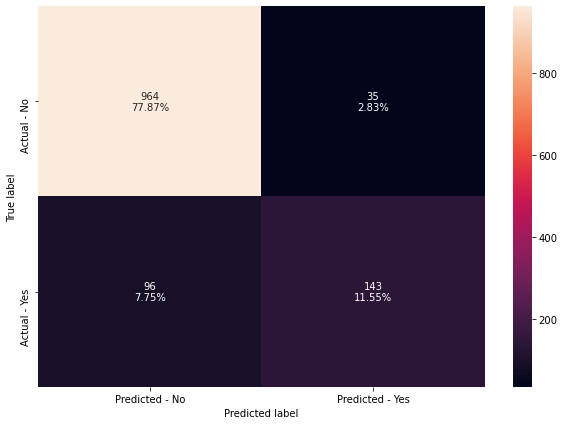

```python
make_confusion_matrix(bagging_estimator,y_test)
```

### Random Forest Classifier

```python
#Train the random forest classifier
rf_estimator=RandomForestClassifier(random_state=1)
rf_estimator.fit(X_train,y_train)
```

```
RandomForestClassifier(random_state=1)
```

#### Evaluate the performance metrics of the Random Forest Classifier

```python
#Calculating different metrics
rf_estimator_train_perf=model_performance_classification_sklearn(rf_estimator,X_train,y_train)
print("Training performance:\n",rf_estimator_train_perf)
rf_estimator_test_perf=model_performance_classification_sklearn(rf_estimator,X_test,y_test)
print("Testing performance:\n",rf_estimator_test_perf)
```

```
Training performance:
    Accuracy  Recall  Precision   F1
0       1.0     1.0        1.0  1.0
Testing performance:
    Accuracy   Recall  Precision        F1
0    0.9063  0.60251   0.872727  0.712871
```

#### Confusion Matrix

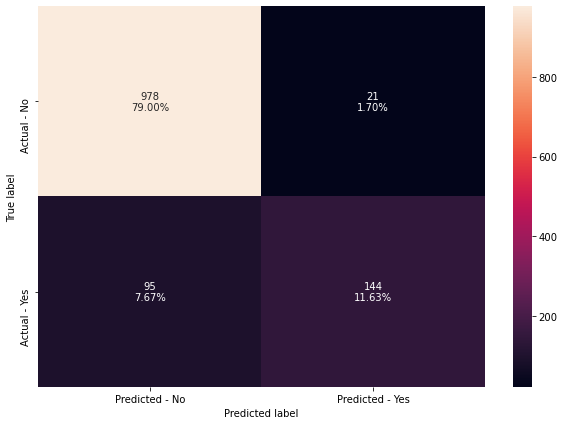

```python
make_confusion_matrix(rf_estimator,y_test)
```

**Observations:**

- **Performance Metrics :** Both models (Random forest and default bagging classifier) seems to be overfitting the training data. The random forest classifier model seems to be overfitting on the training data , even more than the bagging classifier with decision tree. The performance on testing data improved slightly for random forest model in comparision to bagging classifier
- **Confusion Matrix** : The errors, mainly the false positives, with random forest seems to have gone down to 21 from 35 (for bagging classifier)

## Hyperparameter Tuning

### Bagging Classifier

```python
# Bagging Classifier
bagging_estimator_tuned = BaggingClassifier(random_state=1)

# Grid of parameters to choose from
parameters = {'max_samples': [0.7,0.8,0.9,1],
              'max_features': [0.7,0.8,0.9,1],
              'n_estimators' : [10,20,30,40,50],
             }

# Type of scoring used to compare parameter combinations
acc_scorer = metrics.make_scorer(metrics.recall_score)

# Run the grid search
grid_obj = GridSearchCV(bagging_estimator_tuned, parameters, scoring=acc_scorer,cv=5)
grid_obj = grid_obj.fit(X_train, y_train)

# Set the clf to the best combination of parameters
bagging_estimator_tuned = grid_obj.best_estimator_

# Fit the best algorithm to the data.
bagging_estimator_tuned.fit(X_train, y_train)
```

```
BaggingClassifier(max_features=0.9, max_samples=0.8, n_estimators=50,
                  random_state=1)
```

### Insights :

#### Performance Metrics : Hyperparameter Tuning of Bagging Classifier

```python
#Calculating different metrics
bagging_estimator_tuned_train_perf=model_performance_classification_sklearn(bagging_estimator_tuned,X_train,y_train)
print("Training performance:\n",bagging_estimator_tuned_train_perf)
bagging_estimator_tuned_test_perf=model_performance_classification_sklearn(bagging_estimator_tuned,X_test,y_test)
print("Testing performance:\n",bagging_estimator_tuned_test_perf)
```

```
Training performance:
    Accuracy    Recall  Precision      F1
0  0.998267  0.991039        1.0  0.9955
Testing performance:
    Accuracy   Recall  Precision        F1
0  0.902262  0.60251   0.847059  0.704156
```

#### Consufion Matrix : Hyperparameter Tuning

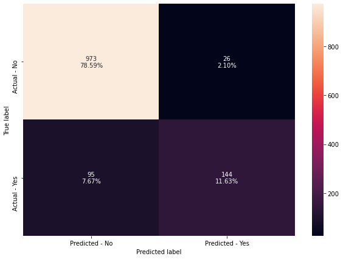

```python
make_confusion_matrix(bagging_estimator_tuned,y_test)
```

### Insights:

- Hyperparameter tuning seemed to have increased false positives.
- Hyperparameter tuning also slightly lowered. the precision in comparision to random forest classifier.

### Tuning Random Forest

```python
# Choose the type of classifier.
rf_tuned = RandomForestClassifier(class_weight={0:0.35,1:0.65},random_state=1)

parameters = {
                'max_depth': list(np.arange(3,10,1)),
                'max_features': np.arange(0.6,1.1,0.1),
                'max_samples': np.arange(0.7,1.1,0.1),
                'min_samples_split': np.arange(2, 20, 5),
                'n_estimators': np.arange(30,160,20),
                'min_impurity_decrease': [0.0001,0.001,0.01,0.1]
}


# Type of scoring used to compare parameter combinations
scorer = metrics.make_scorer(metrics.recall_score)

# Run the grid search
grid_obj = GridSearchCV(rf_tuned, parameters, scoring=scorer,cv=5,n_jobs=-1)
grid_obj = grid_obj.fit(X_train, y_train)

# Set the clf to the best combination of parameters
rf_tuned = grid_obj.best_estimator_

# Fit the best algorithm to the data.
rf_tuned.fit(X_train, y_train)
```

```
RandomForestClassifier(class_weight={0: 0.35, 1: 0.65}, max_depth=9,
                       max_features=0.9999999999999999,
                       max_samples=0.9999999999999999,
                       min_impurity_decrease=0.0001, min_samples_split=12,
                       n_estimators=30, random_state=1)
```

```python
#Calculating different metrics
rf_tuned_train_perf=model_performance_classification_sklearn(rf_tuned,X_train,y_train)
print("Training performance:\n",rf_tuned_train_perf)
rf_tuned_test_perf=model_performance_classification_sklearn(rf_tuned,X_test,y_test)
print("Testing performance:\n",rf_tuned_test_perf)
```

```
Training performance:
    Accuracy    Recall  Precision        F1
0  0.940055  0.777778   0.898551  0.833814
Testing performance:
    Accuracy    Recall  Precision        F1
0  0.859451  0.548117   0.664975  0.600917
```

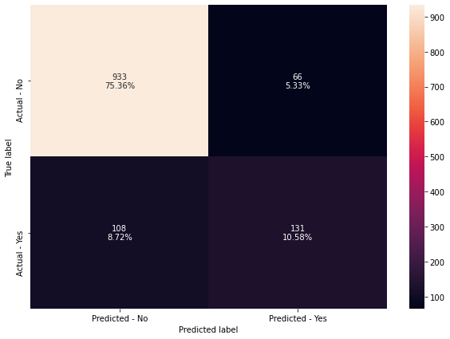

```python
#Creating confusion matrix
make_confusion_matrix(rf_tuned,y_test)
```

**Observations :**

- Random forest tuning seemed to have increased both the errors compared to all other models built earlier
- Random forest tuning also has lowered the performance on both training and testing data.

### Let's try using logistic regression instead of default decision tree as the base estimator for bagging classifier:

```python
bagging_lr=BaggingClassifier(base_estimator=LogisticRegression(random_state=1),random_state=1)
bagging_lr.fit(X_train,y_train)
```

```
BaggingClassifier(base_estimator=LogisticRegression(random_state=1),
                  random_state=1)
```

```python
# #Using above defined function to get accuracy, recall and precision on train and test set
# bagging_lr_score=get_metrics_score(bagging_lr)

#Calculating different metrics
bagging_lr_train_perf=model_performance_classification_sklearn(bagging_lr,X_train,y_train)
print("Training performance:\n",bagging_lr_train_perf)
bagging_lr_test_perf=model_performance_classification_sklearn(bagging_lr,X_test,y_test)
print("Testing performance:\n",bagging_lr_test_perf)
```

```
Training performance:
    Accuracy    Recall  Precision        F1
0  0.829522  0.173835   0.757812  0.282799
Testing performance:
    Accuracy    Recall  Precision        F1
0  0.828756  0.158996    0.77551  0.263889
```

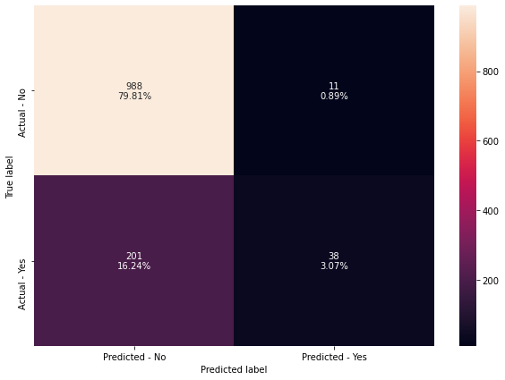

```python
make_confusion_matrix(bagging_lr,y_test)
```

**Observations :**

- Bagging with logistic regression as base classifier seemed to have increased false negatives significantly compared to all other models built earlier
- It also has dramatically lowered the performance on both training and testing data to a unaccepatable range.

We will completely disregard this for our comparision done further

### Random Forest with Class Weights:

```python
# Choose the type of classifier.
rf_estimator_weighted = RandomForestClassifier(random_state=1)

# Grid of parameters to choose from
parameters = {
    "class_weight": [{0: 0.25, 1: 0.75}],
    "n_estimators": [10,20,40,60],
    "min_samples_leaf": np.arange(5, 8),
    "max_features": np.arange(0.2, 0.7, 0.1),
    "max_samples": np.arange(0.3, 0.7, 0.1),
}

# Type of scoring used to compare parameter combinations
acc_scorer = metrics.make_scorer(metrics.recall_score)

# Run the grid search
grid_obj = GridSearchCV(rf_estimator_weighted, parameters, scoring=acc_scorer,cv=5)
grid_obj = grid_obj.fit(X_train, y_train)

# Set the clf to the best combination of parameters
rf_estimator_weighted = grid_obj.best_estimator_

# Fit the best algorithm to the data.
rf_estimator_weighted.fit(X_train, y_train)
```

```
RandomForestClassifier(class_weight={0: 0.25, 1: 0.75},
                       max_features=0.6000000000000001,
                       max_samples=0.6000000000000001, min_samples_leaf=6,
                       n_estimators=10, random_state=1)
```

```python
#Calculating different metrics
rf_estimator_weighted_score_train_perf=model_performance_classification_sklearn(rf_estimator_weighted,X_train,y_train)
print("Training performance:\n",rf_estimator_weighted_score_train_perf)
rf_estimator_weighted_score_test_perf=model_performance_classification_sklearn(rf_estimator_weighted,X_test,y_test)
print("Testing performance:\n",rf_estimator_weighted_score_test_perf)
```

[output not shown]

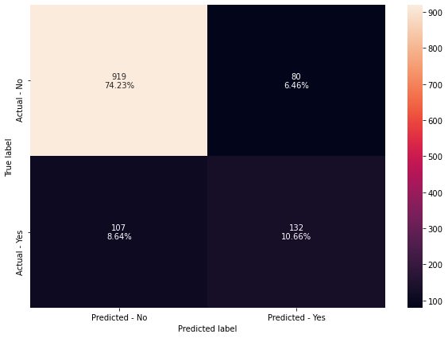

```python
make_confusion_matrix(rf_estimator_weighted,y_test)
```

**Observations :**

## Comparing all the Bagging Classifier models

```python
# training performance comparison

models_train_comp_df = pd.concat(
    [bagging_estimator_train_perf.T,rf_estimator_train_perf.T,bagging_estimator_tuned_train_perf.T,
     rf_tuned_train_perf.T,bagging_lr_train_perf.T , rf_estimator_weighted_score_train_perf.T],
    axis=1,
)
models_train_comp_df.columns = [
    "Decision Tree Estimator",
    "Random Forest Estimator",
    "Bagging Estimator Tuned",
    "Random Forest Tuned",
    "Logistic Regression Bagging Classifier",
    "Random Forest With Weighted Score"]
print("Training performance comparison:")
models_train_comp_df
```

```
Training performance comparison:
```

|  | Decision Tree Estimator | Random Forest Estimator | Bagging Estimator Tuned | Random Forest Tuned | Logistic Regression Bagging Classifier | Random Forest With Weighted Score |
| --- | --- | --- | --- | --- | --- | --- |
| Accuracy | 0.993763 | 1.0 | 0.998267 | 0.940055 | 0.829522 | 0.910949 |
| Recall | 0.967742 | 1.0 | 0.991039 | 0.777778 | 0.173835 | 0.770609 |
| Precision | 1.000000 | 1.0 | 1.000000 | 0.898551 | 0.757812 | 0.769231 |
| F1 | 0.983607 | 1.0 | 0.995500 | 0.833814 | 0.282799 | 0.769919 |

```python
# testing performance comparison
models_test_comp_df = pd.concat(
    [bagging_estimator_test_perf.T,rf_estimator_test_perf.T,bagging_estimator_tuned_test_perf.T,
     rf_tuned_test_perf.T,bagging_lr_test_perf.T , rf_estimator_weighted_score_test_perf.T],
    axis=1,
)
models_test_comp_df.columns = [
    "Decision Tree Estimator",
    "Random Forest Estimator",
    "Bagging Estimator Tuned",
    "Random Forest Tuned",
    "Logistic Regression Bagging Classifier",
    "Random Forest With Weighted Score"]
print("\n\nTesting performance comparison:")
models_test_comp_df
```

```
Testing performance comparison:
```

|  | Decision Tree Estimator | Random Forest Estimator | Bagging Estimator Tuned | Random Forest Tuned | Logistic Regression Bagging Classifier | Random Forest With Weighted Score |
| --- | --- | --- | --- | --- | --- | --- |
| Accuracy | 0.894184 | 0.906300 | 0.902262 | 0.859451 | 0.828756 | 0.848950 |
| Recall | 0.598326 | 0.602510 | 0.602510 | 0.548117 | 0.158996 | 0.552301 |
| Precision | 0.803371 | 0.872727 | 0.847059 | 0.664975 | 0.775510 | 0.622642 |
| F1 | 0.685851 | 0.712871 | 0.704156 | 0.600917 | 0.263889 | 0.585366 |

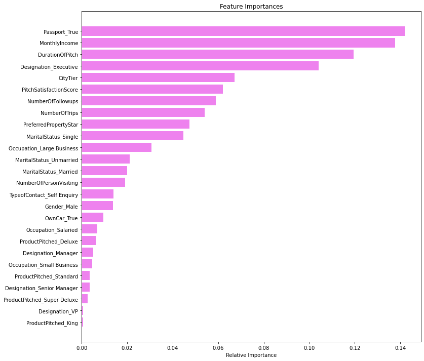

```python
importances = rf_tuned.feature_importances_
indices = np.argsort(importances)
feature_names = list(X.columns)

plt.figure(figsize=(12,12))
plt.title('Feature Importances')
plt.barh(range(len(indices)), importances[indices], color='violet', align='center')
plt.yticks(range(len(indices)), [feature_names[i] for i in indices])
plt.xlabel('Relative Importance')
plt.show()
```

### Boosting Classifier Models

### AdaBoost Classifier

```python
adaBoost_classfr = AdaBoostClassifier(random_state=1)
adaBoost_classfr.fit(X_train,y_train)
```

```
AdaBoostClassifier(random_state=1)
```

```python
#Calculating different metrics
adaBoost_classfr_train_perf=model_performance_classification_sklearn(adaBoost_classfr,X_train,y_train)
print("Training performance:\n",adaBoost_classfr_train_perf)
adaBoost_classfr_test_perf=model_performance_classification_sklearn(adaBoost_classfr,X_test,y_test)
print("Testing performance:\n",adaBoost_classfr_test_perf)
```

```
Training performance:
    Accuracy    Recall  Precision        F1
0  0.843728  0.374552   0.672026  0.481013
Testing performance:
    Accuracy    Recall  Precision        F1
0  0.817447  0.288703      0.552  0.379121
```

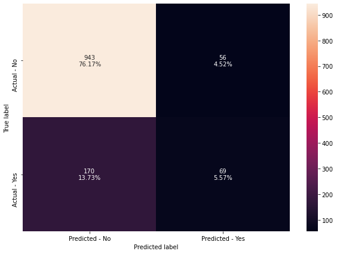

```python
make_confusion_matrix(adaBoost_classfr,y_test)
```

**Observation:**

- The performance of all metrics in Adaboost has been worse than most bagging models
- The False negative errors has also increased in Adaboost compared to most bagging models

### Gradient Boosting Classifier

```python
gradBoost_classfr = GradientBoostingClassifier(random_state=1)
gradBoost_classfr.fit(X_train,y_train)
```

```
GradientBoostingClassifier(random_state=1)
```

```python
#Calculating different metrics
gradBoost_classfr_train_perf=model_performance_classification_sklearn(gradBoost_classfr,X_train,y_train)
print("Training performance:\n",gradBoost_classfr_train_perf)
gradBoost_classfr_test_perf=model_performance_classification_sklearn(gradBoost_classfr,X_test,y_test)
print("Testing performance:\n",gradBoost_classfr_test_perf)
```

```
Training performance:
    Accuracy    Recall  Precision       F1
0  0.892238  0.526882    0.86217  0.65406
Testing performance:
    Accuracy    Recall  Precision        F1
0  0.851373  0.401674    0.70073  0.510638
```

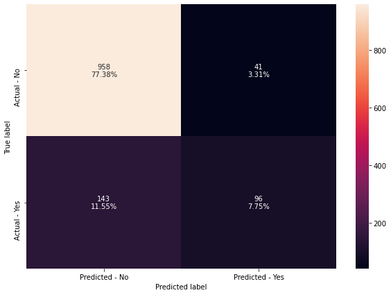

```python
make_confusion_matrix(gradBoost_classfr,y_test)
```

**Observation:**

- The performance of all metrics in Gradient boosting seemed to be better in both training and testing data across all metrics.
- Both the errors have decreased in comparision to Adaboost

### XGBoost Classifier

```python
xgBoost_classfr = XGBClassifier(random_state=1,eval_metric='logloss')
xgBoost_classfr.fit(X_train,y_train)
```

```
XGBClassifier(base_score=0.5, booster='gbtree', colsample_bylevel=1,
              colsample_bynode=1, colsample_bytree=1, eval_metric='logloss',
              gamma=0, gpu_id=-1, importance_type='gain',
              interaction_constraints='', learning_rate=0.300000012,
              max_delta_step=0, max_depth=6, min_child_weight=1, missing=nan,
              monotone_constraints='()', n_estimators=100, n_jobs=12,
              num_parallel_tree=1, random_state=1, reg_alpha=0, reg_lambda=1,
              scale_pos_weight=1, subsample=1, tree_method='exact',
              validate_parameters=1, verbosity=None)
```

```python
#Calculating different metrics
xgBoost_classfr_train_perf=model_performance_classification_sklearn(xgBoost_classfr,X_train,y_train)
print("Training performance:\n",xgBoost_classfr_train_perf)
xgBoost_classfr_test_perf=model_performance_classification_sklearn(xgBoost_classfr,X_test,y_test)
print("Testing performance:\n",xgBoost_classfr_test_perf)
```

```
Training performance:
    Accuracy    Recall  Precision        F1
0  0.999653  0.998208        1.0  0.999103
Testing performance:
    Accuracy   Recall  Precision        F1
0  0.905493  0.65272   0.821053  0.727273
```

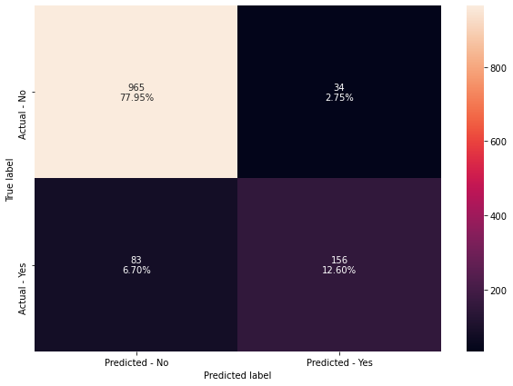

```python
make_confusion_matrix(xgBoost_classfr,y_test)
```

**Observation:**

- Both the errors seemed to have decreased for XGBoost compared to Gradient boosting model
- Both the training data and testing data for XGBoost seemed to have improved.
- The model seems to overfit the training data.

## Hyperparameter Tuning

### AdaBoost Classifier with Hyperparameter Tuning

```python
# Choose the type of classifier.
adaBoost_classfr_tuned = AdaBoostClassifier(random_state=1)

# Grid of parameters to choose from
parameters = {
    #Let's try different max_depth for base_estimator
    "base_estimator":[DecisionTreeClassifier(max_depth=1, random_state=1),DecisionTreeClassifier(max_depth=2, random_state=1),DecisionTreeClassifier(max_depth=3, random_state=1),DecisionTreeClassifier(max_depth=4, random_state=1)],
    "n_estimators": np.arange(10,110,10),
    "learning_rate":np.arange(0.1,2,0.1)
}

# Type of scoring used to compare parameter combinations
acc_scorer = metrics.make_scorer(metrics.recall_score)

# Run the grid search
grid_obj = GridSearchCV(adaBoost_classfr_tuned, parameters, scoring=acc_scorer,cv=5)
grid_obj = grid_obj.fit(X_train, y_train)

# Set the clf to the best combination of parameters
adaBoost_classfr_tuned = grid_obj.best_estimator_

# Fit the best algorithm to the data.
adaBoost_classfr_tuned.fit(X_train, y_train)
```

```
AdaBoostClassifier(base_estimator=DecisionTreeClassifier(max_depth=4,
                                                         random_state=1),
                   learning_rate=1.5000000000000002, n_estimators=30,
                   random_state=1)
```

**Observation:**

The best attributes as per grid search:

- max_depth = 4
- learning_rate = 1.5
- n_estimators = 30

```python
#Calculating different metrics
adaBoost_classfr_tuned_train_perf=model_performance_classification_sklearn(adaBoost_classfr_tuned,X_train,y_train)
print("Training performance:\n",adaBoost_classfr_tuned_train_perf)
adaBoost_classfr_tuned_test_perf=model_performance_classification_sklearn(adaBoost_classfr_tuned,X_test,y_test)
print("Testing performance:\n",adaBoost_classfr_tuned_test_perf)
```

[output not shown]

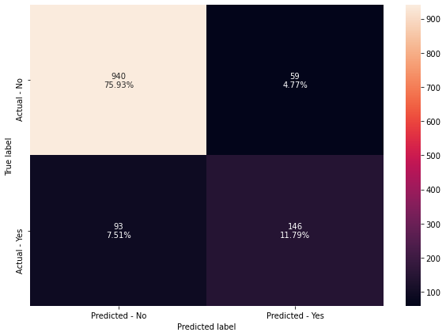

```python
make_confusion_matrix(adaBoost_classfr_tuned,y_test)
```

**Observation:**

- AdaBoost with tuning has a lower performance compared to XGBoost in both training and testing data. This was mainly because XGBoost was overfitting the training data
- Both the errors have increased in comparision to XGBoost.

### GradientBoost Classifier with Hyperparameter Tuning

```python
# Choose the type of classifier.
gbc_tuned = GradientBoostingClassifier(init=AdaBoostClassifier(random_state=1),random_state=1)

# Grid of parameters to choose from
## add from article
parameters = {
    "n_estimators": [100,150,200,250],
    "subsample":[0.8,0.9,1],
    "max_features":[0.7,0.8,0.9,1]
}

# Type of scoring used to compare parameter combinations
acc_scorer = metrics.make_scorer(metrics.recall_score)

# Run the grid search
grid_obj = GridSearchCV(gbc_tuned, parameters, scoring=acc_scorer,cv=5)
grid_obj = grid_obj.fit(X_train, y_train)

# Set the clf to the best combination of parameters
gbc_tuned = grid_obj.best_estimator_

# Fit the best algorithm to the data.
gbc_tuned.fit(X_train, y_train)
```

```
GradientBoostingClassifier(init=AdaBoostClassifier(random_state=1),
                           max_features=0.7, n_estimators=250, random_state=1,
                           subsample=0.9)
```

```python
#Calculating different metrics
gbc_tuned_train_perf=model_performance_classification_sklearn(gbc_tuned,X_train,y_train)
print("Training performance:\n",gbc_tuned_train_perf)
gbc_tuned_test_perf=model_performance_classification_sklearn(gbc_tuned,X_test,y_test)
print("Testing performance:\n",gbc_tuned_test_perf)
```

```
Training performance:
    Accuracy    Recall  Precision        F1
0  0.926888  0.668459   0.934837  0.779519
Testing performance:
    Accuracy    Recall  Precision        F1
0  0.855412  0.456067   0.689873  0.549118
```

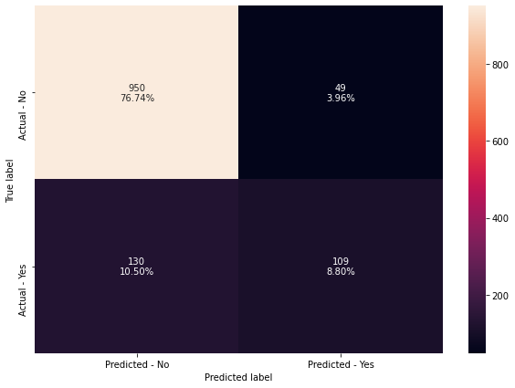

```python
make_confusion_matrix(gbc_tuned,y_test)
```

**Observation:**

### Comparing all Boosting Classifier Models

### Training Performance Comparision : All Boosting Classifier Models

```python
# training performance comparison

models_train_comp_df = pd.concat(
    [adaBoost_classfr_train_perf.T,gradBoost_classfr_train_perf.T,xgBoost_classfr_train_perf.T,
     adaBoost_classfr_tuned_train_perf.T,gbc_tuned_train_perf.T ],
    axis=1,
)
models_train_comp_df.columns = [
    "AdaBoost Classifier",
    "GradientBoost Classifier",
    "XGBoost Classifier",
    "AdaBoost Classifier Tuned",
    "GradientBoost Classifier Tuned"]

print("Training performance comparison:")
models_train_comp_df
```

```
Training performance comparison:
```

|  | AdaBoost Classifier | GradientBoost Classifier | XGBoost Classifier | AdaBoost Classifier Tuned | GradientBoost Classifier Tuned |
| --- | --- | --- | --- | --- | --- |
| Accuracy | 0.843728 | 0.892238 | 0.999653 | 0.978170 | 0.926888 |
| Recall | 0.374552 | 0.526882 | 0.998208 | 0.926523 | 0.668459 |
| Precision | 0.672026 | 0.862170 | 1.000000 | 0.959184 | 0.934837 |
| F1 | 0.481013 | 0.654060 | 0.999103 | 0.942571 | 0.779519 |

### Testing Performance Comparision : All Boosting Classifier Models

```python
# Testing performance comparision
models_test_comp_df = pd.concat(
    [adaBoost_classfr_test_perf.T,gradBoost_classfr_test_perf.T,xgBoost_classfr_test_perf.T,
     adaBoost_classfr_tuned_test_perf.T,gbc_tuned_test_perf.T ],
    axis=1,
)
models_test_comp_df.columns = [
    "AdaBoost Classifier",
    "GradientBoost Classifier",
    "XGBoost Classifier",
    "AdaBoost Classifier Tuned",
    "GradientBoost Classifier Tuned"]

print("Testing performance comparison:")
models_test_comp_df
```

```
Testing performance comparison:
```

[output not shown]

### Summary : Comparing Best Bagging and Boosting Models

```python
# training performance comparison of few of the best bagging and Boosting models

models_train_comp_df = pd.concat(
    [bagging_estimator_train_perf.T, rf_tuned_train_perf.T, rf_estimator_weighted_score_train_perf.T ,
     xgBoost_classfr_train_perf.T,
     adaBoost_classfr_tuned_train_perf.T ],
    axis=1,
)
models_train_comp_df.columns = [
    "Decision Tree Estimator",
    "Random Forest Tuned",
    "Random Forest With Weighted Score",
    "XGBoost Classifier",
    "AdaBoost Classifier Tuned"]

print("Training performance comparison:")
models_train_comp_df
```

```
Training performance comparison:
```

|  | Decision Tree Estimator | Random Forest Tuned | Random Forest With Weighted Score | XGBoost Classifier | AdaBoost Classifier Tuned |
| --- | --- | --- | --- | --- | --- |
| Accuracy | 0.993763 | 0.940055 | 0.910949 | 0.999653 | 0.978170 |
| Recall | 0.967742 | 0.777778 | 0.770609 | 0.998208 | 0.926523 |
| Precision | 1.000000 | 0.898551 | 0.769231 | 1.000000 | 0.959184 |
| F1 | 0.983607 | 0.833814 | 0.769919 | 0.999103 | 0.942571 |

```python
# testing performance comparison of few of the best bagging and Boosting models

models_test_comp_df = pd.concat(
    [bagging_estimator_test_perf.T, rf_tuned_test_perf.T, rf_estimator_weighted_score_test_perf.T ,
     xgBoost_classfr_test_perf.T,
     adaBoost_classfr_tuned_test_perf.T ],
    axis=1,
)
models_test_comp_df.columns = [
    "Decision Tree Estimator",
    "Random Forest Tuned",
    "Random Forest With Weighted Score",
    "XGBoost Classifier",
    "AdaBoost Classifier Tuned"]

print("Testing performance comparison:")
models_test_comp_df
```

```
Testing performance comparison:
```

|  | Decision Tree Estimator | Random Forest Tuned | Random Forest With Weighted Score | XGBoost Classifier | AdaBoost Classifier Tuned |
| --- | --- | --- | --- | --- | --- |
| Accuracy | 0.894184 | 0.859451 | 0.848950 | 0.905493 | 0.877221 |
| Recall | 0.598326 | 0.548117 | 0.552301 | 0.652720 | 0.610879 |
| Precision | 0.803371 | 0.664975 | 0.622642 | 0.821053 | 0.712195 |
| F1 | 0.685851 | 0.600917 | 0.585366 | 0.727273 | 0.657658 |

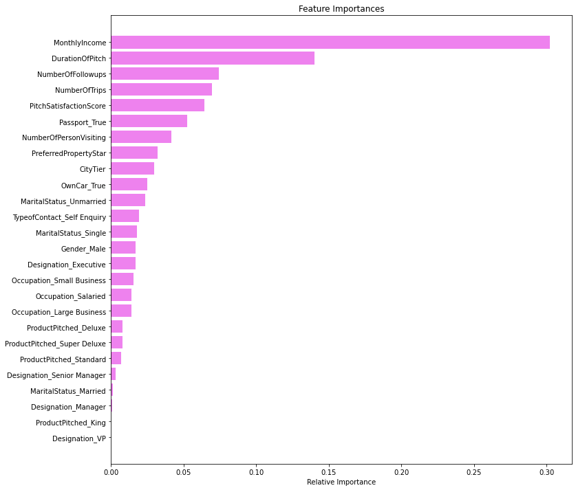

```python
importances = adaBoost_classfr_tuned.feature_importances_
indices = np.argsort(importances)
feature_names = list(X.columns)

plt.figure(figsize=(12,12))
plt.title('Feature Importances')
plt.barh(range(len(indices)), importances[indices], color='violet', align='center')
plt.yticks(range(len(indices)), [feature_names[i] for i in indices])
plt.xlabel('Relative Importance')
plt.show()
```

### Finalized Model : AdaCoost Classifer Model with Hypertuning

**Customer Attributes to Consider In Marketing/Sales Reachout to increase the likelihood of customer accepting the travel package:**

- Monthly Income of the customer
- Duration of Sales Pitch by the sales team
- Number of Followups done by the sales personale
- Satisfaction score of the sales pitch
- Customer who possess a passport